# ENDC Multi-Connectivity Operation Related Aspects

This article will focus on the mobility of EN-DC, for more scenarios please find TS37.340 for more information.

EN-DC mobility scenatios are:

1. Secondary Node Modification (MN/SN initiated)
2. Secondary Node change (MN/SN initiated)
3. PSCell Change
4. Inter-Master Node Handover with/without Secondary Node change

## Secondary Node Modification (MN/SN initiated)

[figure not shown]

The MN uses the procedure to initiate configuration changes of the SCG within the same SN, e.g. the addition, modification or release of SCG bearer(s) and the SCG RLC bearer of split bearer(s), as well as configuration changes for SN terminated MCG bearers. **Bearer termination point change is realized by adding the new bearer configuration and releasing the old bearer configuration within a single MN initiated SN Modification procedure for the respective ERAB.** The MN uses this procedure to perform handover within the same MN while keeping the SN. The MN also uses the procedure to query the current SCG configuration, e.g. when delta configuration is applied in a MN initiated SN change. The MN also uses the procedure to provide the S-RLF related information to the SN. The MN may not use the procedure to initiate the addition, modification or release of SCG SCells. The SN may reject the request, except if it concerns the release of SN terminated bearer(s) or the SCG RLC bearer of MN terminated bearer(s), or if it is used to perform handover within the same MN while keeping the SN. Figure 10.3.1-1 shows an example signalling flow for a MN initiated SN Modification procedure.

## Secondary Node Modification (MN/SN initiated)

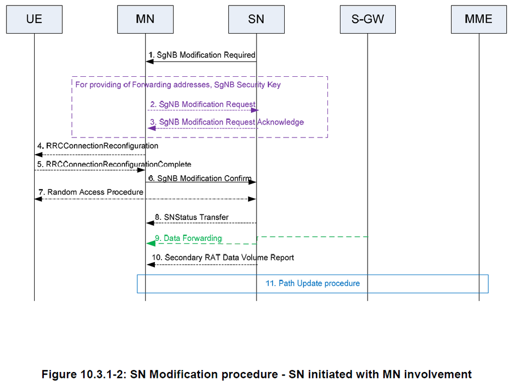

## Secondary Node change (MN/SN initiated)

The Secondary Node Change procedure is initiated either by MN or SN and used to transfer a UE context from a source SN to a target SN and to change the SCG configuration in UE from one SN to another.

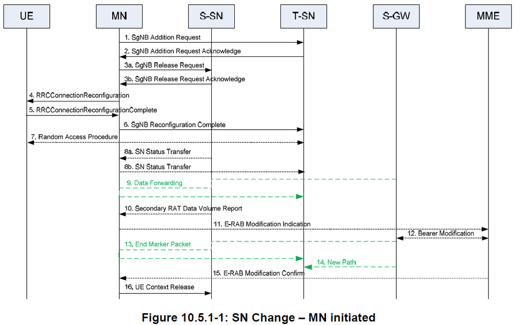

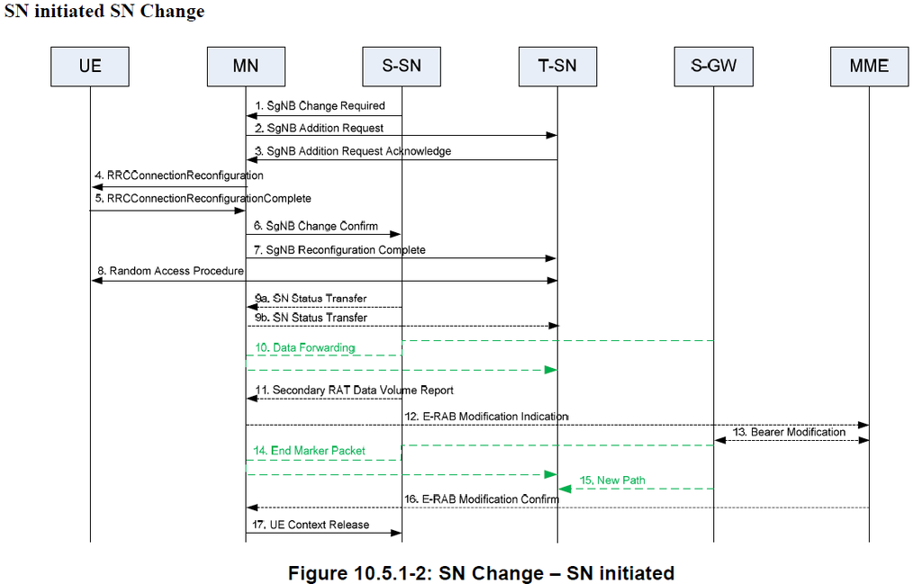

## PSCell Change

SN Modification procedure is used.

## Inter-Master Node Handover with/without Secondary Node change

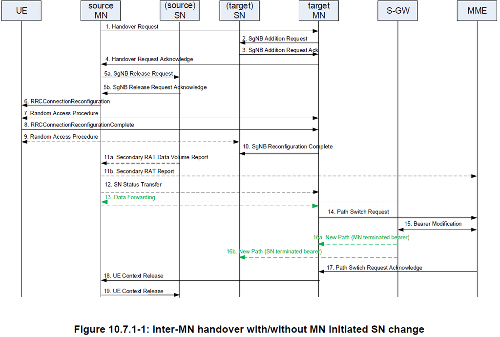

=======================================================================  
The best way to know the actual EN-DC mobility is to have live trace logs which have RRC/X2AP/S1AP, but I don’t have that at hand at this point of time. What I can do is to UE log (RRC/NR RRC) analysis first.

## LTE RRC Connection Feconfiguration

TS36.331

RRCConnectionReconfiguration-v1510-IEs ::= SEQUENCE {  
nr-Config-r15 CHOICE {  
release NULL,  
setup SEQUENCE {  
**endc-ReleaseAndAdd-r15 BOOLEAN**,  
**nr-SecondaryCellGroupConfig-r15 OCTET STRING OPTIONAL, – Need ON**  
p-MaxEUTRA-r15 P-Max OPTIONAL – Need ON  
}  
} OPTIONAL, – Need ON  
sk-Counter-r15 INTEGER (0.. 65535) OPTIONAL, – Need ON  
nr-RadioBearerConfig1-r15 OCTET STRING OPTIONAL, – Need ON  
nr-RadioBearerConfig2-r15 OCTET STRING OPTIONAL, – Need ON  
tdm-PatternConfig-r15 CHOICE {  
release NULL,  
setup SEQUENCE {  
subframeAssignment-r15 SubframeAssignment-r15,  
harq-Offset-r15 INTEGER (0.. 9)  
}  
} OPTIONAL, – Cond FDD-PCell  
nonCriticalExtension RRCConnectionReconfiguration-v1530-IEs OPTIONAL  
}

### endc-ReleaseAndAdd

A one-shot field indicating whether the UE simultaneously releases and adds all the NR SCG related configuration within nr-Config, i.e. the configuration set by the NR RRCReconfiguration message (e.g. secondaryCellGroup, SRB3 and measConfig).

### nr-SecondaryCellGroupConfig

Includes the NR RRCReconfiguration message as specified in TS 38.331 [82]. In this version of the specification, the NR RRC message only includes fields secondaryCellGroup and/ or measConfig. **If nr-SecondaryCellGroupConfig is configured, the network always includes this field upon MN handover to initiate an NR SCG reconfiguration with sync and key change.**

## Example - SN PSCell Change

LTE_Uu_RRC: DL_DCCH_Message  
- . .message:- c1:- rrcConnectionReconfiguration  
- . . . . .rrc-TransactionIdentifier: 3  
- . . . . .criticalExtensions:- c1:- rrcConnectionReconfiguration-r8  
- . . . . . . . .nonCriticalExtension  
- . . . . . . . . .nonCriticalExtension  
- . . . . . . . . . .nonCriticalExtension  
- . . . . . . . . . . .nonCriticalExtension  
- . . . . . . . . . . . .nonCriticalExtension  
- . . . . . . . . . . . . .nonCriticalExtension  
- . . . . . . . . . . . . . .nonCriticalExtension  
- . . . . . . . . . . . . . . .nonCriticalExtension  
- . . . . . . . . . . . . . . . .nr-Config-r15:- setup  
- . . . . . . . . . . . . . . . . . .endc-ReleaseAndAdd-r15: 1  
- . . . . . . . . . . . . . . . . . .nr-SecondaryCellGroupConfig-r15: 0x0c81445c40b04431c55fc8120dc4e80f

LTE_Uu_RRC: DL_DCCH_Message  
- . .message:- c1:- rrcConnectionReconfiguration  
- . . . . .rrc-TransactionIdentifier: 1  
- . . . . .criticalExtensions:- c1:- rrcConnectionReconfiguration-r8  
- . . . . . . . .measConfig  
- . . . . . . . . .measObjectToRemoveList [ 0 ]: 2  
- . . . . . . . . .measObjectToRemoveList [ 1 ]: 5  
- . . . . . . . . .measObjectToAddModList [ 0 ]  
- . . . . . . . . . .measObjectId: 3  
- . . . . . . . . . .measObject:- measObjectEUTRA  
- . . . . . . . . . . . .carrierFreq: ****  
- . . . . . . . . . . . .allowedMeasBandwidth: 5 ( mbw100)  
- . . . . . . . . . . . .presenceAntennaPort1: 0 (False)  
- . . . . . . . . . . . .neighCellConfig: 2  
- . . . . . . . . . . . .measCycleSCell-r10: 0  
- . . . . . . . . .measObjectToAddModList [ 1 ]  
- . . . . . . . . . .measObjectId: 4  
- . . . . . . . . . .measObject:- measObjectEUTRA  
- . . . . . . . . . . . .carrierFreq: ****  
- . . . . . . . . . . . .allowedMeasBandwidth: 5 ( mbw100)  
- . . . . . . . . . . . .presenceAntennaPort1: 0 (False)  
- . . . . . . . . . . . .neighCellConfig: 2  
- . . . . . . . . . . . .measCycleSCell-r10: 0  
- . . . . . . . . .measObjectToAddModList [ 2 ]  
- . . . . . . . . . .measObjectId: 1  
- . . . . . . . . . .measObject:- measObjectEUTRA  
- . . . . . . . . . . . .carrierFreq: ****  
- . . . . . . . . . . . .allowedMeasBandwidth: 3 ( mbw50)  
- . . . . . . . . . . . .presenceAntennaPort1: 0 (False)  
- . . . . . . . . . . . .neighCellConfig: 2  
- . . . . . . . . .reportConfigToRemoveList [ 0 ]: 3  
- . . . . . . . . .reportConfigToRemoveList [ 1 ]: 4  
- . . . . . . . . .reportConfigToRemoveList [ 2 ]: 6  
- . . . . . . . . .reportConfigToRemoveList [ 3 ]: 8  
- . . . . . . . . .reportConfigToAddModList [ 0 ]  
- . . . . . . . . . .reportConfigId: 10  
- . . . . . . . . . .reportConfig:- reportConfigEUTRA  
- . . . . . . . . . . . .triggerType:- event  
- . . . . . . . . . . . . . .eventId:- eventA2  
- . . . . . . . . . . . . . . . .a2-Threshold:- threshold-RSRP: 0 (-140.00 dBm)  
- . . . . . . . . . . . . . .hysteresis: 2 (1.0 dB)  
- . . . . . . . . . . . . . .timeToTrigger: 15 ( ms5120)  
- . . . . . . . . . . . .triggerQuantity: 0 ( rsrp)  
- . . . . . . . . . . . .reportQuantity: 1 ( both)  
- . . . . . . . . . . . .maxReportCells: 1  
- . . . . . . . . . . . .reportInterval: 2 ( ms480)  
- . . . . . . . . . . . .reportAmount: 7 ( infinity)  
- . . . . . . . . .reportConfigToAddModList [ 1 ]  
- . . . . . . . . . .reportConfigId: 11  
- . . . . . . . . . .reportConfig:- reportConfigEUTRA  
- . . . . . . . . . . . .triggerType:- event  
- . . . . . . . . . . . . . .eventId:- eventA2  
- . . . . . . . . . . . . . . . .a2-Threshold:- threshold-RSRP: 0 (-140.00 dBm)  
- . . . . . . . . . . . . . .hysteresis: 2 (1.0 dB)  
- . . . . . . . . . . . . . .timeToTrigger: 15 ( ms5120)  
- . . . . . . . . . . . .triggerQuantity: 0 ( rsrp)  
- . . . . . . . . . . . .reportQuantity: 1 ( both)  
- . . . . . . . . . . . .maxReportCells: 1  
- . . . . . . . . . . . .reportInterval: 2 ( ms480)  
- . . . . . . . . . . . .reportAmount: 7 ( infinity)  
- . . . . . . . . .reportConfigToAddModList [ 2 ]  
- . . . . . . . . . .reportConfigId: 1  
- . . . . . . . . . .reportConfig:- reportConfigEUTRA  
- . . . . . . . . . . . .triggerType:- event  
- . . . . . . . . . . . . . .eventId:- eventA3  
- . . . . . . . . . . . . . . . .a3-Offset: 4 (2.0 dB)  
- . . . . . . . . . . . . . . . .reportOnLeave: 0 (False)  
- . . . . . . . . . . . . . .hysteresis: 2 (1.0 dB)  
- . . . . . . . . . . . . . .timeToTrigger: 6 ( ms160)  
- . . . . . . . . . . . .triggerQuantity: 0 ( rsrp)  
- . . . . . . . . . . . .reportQuantity: 1 ( both)  
- . . . . . . . . . . . .maxReportCells: 4  
- . . . . . . . . . . . .reportInterval: 2 ( ms480)  
- . . . . . . . . . . . .reportAmount: 7 ( infinity)  
- . . . . . . . . .reportConfigToAddModList [ 3 ]  
- . . . . . . . . . .reportConfigId: 2  
- . . . . . . . . . .reportConfig:- reportConfigEUTRA  
- . . . . . . . . . . . .triggerType:- event  
- . . . . . . . . . . . . . .eventId:- eventA2  
- . . . . . . . . . . . . . . . .a2-Threshold:- threshold-RSRP: 32 (-108.00 dBm)  
- . . . . . . . . . . . . . .hysteresis: 4 (2.0 dB)  
- . . . . . . . . . . . . . .timeToTrigger: 13 ( ms1280)  
- . . . . . . . . . . . .triggerQuantity: 0 ( rsrp)  
- . . . . . . . . . . . .reportQuantity: 1 ( both)  
- . . . . . . . . . . . .maxReportCells: 1  
- . . . . . . . . . . . .reportInterval: 6 ( ms5120)  
- . . . . . . . . . . . .reportAmount: 7 ( infinity)  
- . . . . . . . . .measIdToRemoveList [ 0 ]: 3  
- . . . . . . . . .measIdToRemoveList [ 1 ]: 4  
- . . . . . . . . .measIdToRemoveList [ 2 ]: 6  
- . . . . . . . . .measIdToRemoveList [ 3 ]: 8  
- . . . . . . . . .measIdToAddModList [ 0 ]  
- . . . . . . . . . .measId: 10  
- . . . . . . . . . .measObjectId: 3  
- . . . . . . . . . .reportConfigId: 10  
- . . . . . . . . .measIdToAddModList [ 1 ]  
- . . . . . . . . . .measId: 11  
- . . . . . . . . . .measObjectId: 4  
- . . . . . . . . . .reportConfigId: 11  
- . . . . . . . . .measIdToAddModList [ 2 ]  
- . . . . . . . . . .measId: 1  
- . . . . . . . . . .measObjectId: 1  
- . . . . . . . . . .reportConfigId: 1  
- . . . . . . . . .measIdToAddModList [ 3 ]  
- . . . . . . . . . .measId: 2  
- . . . . . . . . . .measObjectId: 1  
- . . . . . . . . . .reportConfigId: 2  
- . . . . . . . . .quantityConfig  
- . . . . . . . . . .quantityConfigEUTRA  
- . . . . . . . . . . .filterCoefficientRSRQ: 10 ( fc11)  
- . . . . . . . . . .quantityConfigUTRA  
- . . . . . . . . . . .measQuantityUTRA-FDD: 0 ( cpich_RSCP)  
- . . . . . . . . . . .measQuantityUTRA-TDD: 0 ( pccpch_RSCP)  
- . . . . . . . . . .quantityConfigGERAN  
- . . . . . . . . . . .measQuantityGERAN: 0 ( rssi)  
- . . . . . . . . . . .filterCoefficient: 4 ( fc4)  
- . . . . . . . . . .quantityConfigUTRA-v1020  
- . . . . . . . . . .quantityConfigNRList-r15 [ 0 ]  
- . . . . . . . . . . .measQuantityCellNR-r15  
- . . . . . . . .**mobilityControlInfo**  
- . . . . . . . . .**targetPhysCellId: 208**  
- . . . . . . . . .**carrierFreq**  
- . . . . . . . . . .**dl-CarrierFreq:** ** **  
- . . . . . . . . .carrierBandwidth  
- . . . . . . . . . .dl-Bandwidth: 3 ( n50)  
- . . . . . . . . .additionalSpectrumEmission: 1  
- . . . . . . . . .t304: 5 ( ms1000)  
- . . . . . . . . .newUE-Identity: 3181 (0xC6D)  
- . . . . . . . . .radioResourceConfigCommon  
- . . . . . . . . . .rach-ConfigCommon  
- . . . . . . . . . . .preambleInfo  
- . . . . . . . . . . . .numberOfRA-Preambles: 12 ( n52)  
- . . . . . . . . . . .powerRampingParameters  
- . . . . . . . . . . . .powerRampingStep: 2 ( dB4)  
- . . . . . . . . . . . .preambleInitialReceivedTargetPower: 5 ( dBm_110)  
- . . . . . . . . . . .ra-SupervisionInfo  
- . . . . . . . . . . . .preambleTransMax: 6 ( n10)  
- . . . . . . . . . . . .ra-ResponseWindowSize: 7 ( sf10)  
- . . . . . . . . . . . .mac-ContentionResolutionTimer: 7 ( sf64)  
- . . . . . . . . . . .maxHARQ-Msg3Tx: 4  
- . . . . . . . . . .prach-Config  
- . . . . . . . . . . .rootSequenceIndex: 570  
- . . . . . . . . . . .prach-ConfigInfo  
- . . . . . . . . . . . .prach-ConfigIndex: 3  
- . . . . . . . . . . . .highSpeedFlag: 0 (False)  
- . . . . . . . . . . . .zeroCorrelationZoneConfig: 12 (12)  
- . . . . . . . . . . . .prach-FreqOffset: 3  
- . . . . . . . . . .pdsch-ConfigCommon  
- . . . . . . . . . . .referenceSignalPower: 15 (15.0 dBm)  
- . . . . . . . . . . .p-b: 0  
- . . . . . . . . . .pusch-ConfigCommon  
- . . . . . . . . . . .pusch-ConfigBasic  
- . . . . . . . . . . . .n-SB: 1 (1)  
- . . . . . . . . . . . .hoppingMode: 0 ( interSubFrame)  
- . . . . . . . . . . . .pusch-HoppingOffset: 0  
- . . . . . . . . . . . .enable64QAM: 1 (True)  
- . . . . . . . . . . .ul-ReferenceSignalsPUSCH  
- . . . . . . . . . . . .groupHoppingEnabled: 1 (True)  
- . . . . . . . . . . . .groupAssignmentPUSCH: 0  
- . . . . . . . . . . . .sequenceHoppingEnabled: 0 (0)  
- . . . . . . . . . . . .cyclicShift: 0  
- . . . . . . . . . .phich-Config  
- . . . . . . . . . . .phich-Duration: 0 ( normal)  
- . . . . . . . . . . .phich-Resource: 2 ( one)  
- . . . . . . . . . .pucch-ConfigCommon  
- . . . . . . . . . . .deltaPUCCH-Shift: 0 ( ds1)  
- . . . . . . . . . . .nRB-CQI: 3  
- . . . . . . . . . . .nCS-AN: 0  
- . . . . . . . . . . .n1PUCCH-AN: 28  
- . . . . . . . . . .soundingRS-UL-ConfigCommon:- release: null  
- . . . . . . . . . .uplinkPowerControlCommon  
- . . . . . . . . . . .p0-NominalPUSCH: -80 (-80.0 dBm)  
- . . . . . . . . . . .alpha: 5 ( al08)  
- . . . . . . . . . . .p0-NominalPUCCH: -113 (-113.0 dBm)  
- . . . . . . . . . . .deltaFList-PUCCH  
- . . . . . . . . . . . .deltaF-PUCCH-Format1: 1 ( deltaF0)  
- . . . . . . . . . . . .deltaF-PUCCH-Format1b: 1 ( deltaF3)  
- . . . . . . . . . . . .deltaF-PUCCH-Format2: 1 ( deltaF0)  
- . . . . . . . . . . . .deltaF-PUCCH-Format2a: 1 ( deltaF0)  
- . . . . . . . . . . . .deltaF-PUCCH-Format2b: 1 ( deltaF0)  
- . . . . . . . . . . .deltaPreambleMsg3: 6 (12.0 dB)  
- . . . . . . . . . .antennaInfoCommon  
- . . . . . . . . . . .antennaPortsCount: 1 ( an2)  
- . . . . . . . . . .ul-CyclicPrefixLength: 0 ( len1)  
- . . . . . . . . . .uplinkPowerControlCommon-v1020  
- . . . . . . . . . . .deltaF-PUCCH-Format3-r10: 1  
- . . . . . . . . . . .deltaF-PUCCH-Format1bCS-r10: 1  
- . . . . . . . . . .pusch-ConfigCommon-v1270  
- . . . . . . . . . . .enable64QAM-v1270: 0  
- . . . . . . . . .rach-ConfigDedicated  
- . . . . . . . . . .ra-PreambleIndex: 52  
- . . . . . . . . . .ra-PRACH-MaskIndex: 0  
- . . . . . . . .radioResourceConfigDedicated  
- . . . . . . . . .srb-ToAddModList [ 0 ]  
- . . . . . . . . . .srb-Identity: 1  
- . . . . . . . . . .rlc-Config:- explicitValue:- am  
- . . . . . . . . . . . . .ul-AM-RLC  
- . . . . . . . . . . . . . .t-PollRetransmit: 15 ( ms80)  
- . . . . . . . . . . . . . .pollPDU: 7 ( pInfinity)  
- . . . . . . . . . . . . . .pollByte: 14 ( kBinfinity)  
- . . . . . . . . . . . . . .maxRetxThreshold: 7 ( t32)  
- . . . . . . . . . . . . .dl-AM-RLC  
- . . . . . . . . . . . . . .t-Reordering: 7 ( ms35)  
- . . . . . . . . . . . . . .t-StatusProhibit: 0 ( ms0)  
- . . . . . . . . . .logicalChannelConfig:- defaultValue: null  
- . . . . . . . . .srb-ToAddModList [ 1 ]  
- . . . . . . . . . .srb-Identity: 2  
- . . . . . . . . . .rlc-Config:- explicitValue:- am  
- . . . . . . . . . . . . .ul-AM-RLC  
- . . . . . . . . . . . . . .t-PollRetransmit: 15 ( ms80)  
- . . . . . . . . . . . . . .pollPDU: 7 ( pInfinity)  
- . . . . . . . . . . . . . .pollByte: 14 ( kBinfinity)  
- . . . . . . . . . . . . . .maxRetxThreshold: 7 ( t32)  
- . . . . . . . . . . . . .dl-AM-RLC  
- . . . . . . . . . . . . . .t-Reordering: 7 ( ms35)  
- . . . . . . . . . . . . . .t-StatusProhibit: 0 ( ms0)  
- . . . . . . . . . .logicalChannelConfig:- defaultValue: null  
- . . . . . . . . .drb-ToAddModList [ 0 ]  
- . . . . . . . . . .eps-BearerIdentity: 5  
- . . . . . . . . . .drb-Identity: 3  
- . . . . . . . . . .rlc-Config:- am  
- . . . . . . . . . . . .ul-AM-RLC  
- . . . . . . . . . . . . .t-PollRetransmit: 15 ( ms80)  
- . . . . . . . . . . . . .pollPDU: 2 ( p16)  
- . . . . . . . . . . . . .pollByte: 14 ( kBinfinity)  
- . . . . . . . . . . . . .maxRetxThreshold: 7 ( t32)  
- . . . . . . . . . . . .dl-AM-RLC  
- . . . . . . . . . . . . .t-Reordering: 5 ( ms25)  
- . . . . . . . . . . . . .t-StatusProhibit: 0 ( ms0)  
- . . . . . . . . . .logicalChannelIdentity: 3  
- . . . . . . . . . .logicalChannelConfig  
- . . . . . . . . . . .ul-SpecificParameters  
- . . . . . . . . . . . .priority: 11  
- . . . . . . . . . . . .prioritisedBitRate: 1  
- . . . . . . . . . . . .bucketSizeDuration: 0  
- . . . . . . . . . . . .logicalChannelGroup: 3  
- . . . . . . . . .mac-MainConfig:- explicitValue  
- . . . . . . . . . . .ul-SCH-Config  
- . . . . . . . . . . . .maxHARQ-Tx: 3 ( n4)  
- . . . . . . . . . . . .periodicBSR-Timer: 0 ( sf5)  
- . . . . . . . . . . . .retxBSR-Timer: 0 ( sf320)  
- . . . . . . . . . . . .ttiBundling: 0 (False)  
- . . . . . . . . . . .drx-Config:- setup  
- . . . . . . . . . . . . .onDurationTimer: 1 ( psf2)  
- . . . . . . . . . . . . .drx-InactivityTimer: 14 ( psf100)  
- . . . . . . . . . . . . .drx-RetransmissionTimer: 2 ( psf4)  
- . . . . . . . . . . . . .longDRX-CycleStartOffset:- sf320: 12  
- . . . . . . . . . . . . .shortDRX  
- . . . . . . . . . . . . . .shortDRX-Cycle: 5 ( sf20)  
- . . . . . . . . . . . . . .drxShortCycleTimer: 1  
- . . . . . . . . . . .timeAlignmentTimerDedicated: 7 ( infinity)  
- . . . . . . . . . . .phr-Config:- setup  
- . . . . . . . . . . . . .periodicPHR-Timer: 4 ( sf200)  
- . . . . . . . . . . . . .prohibitPHR-Timer: 5 ( sf200)  
- . . . . . . . . . . . . .dl-PathlossChange: 1 ( dB3)  
- . . . . . . . . . . .mac-MainConfig-v1020  
- . . . . . . . . .physicalConfigDedicated  
- . . . . . . . . . .pdsch-ConfigDedicated  
- . . . . . . . . . . .p-a: 4 ( dB0)  
- . . . . . . . . . .pusch-ConfigDedicated  
- . . . . . . . . . . .betaOffset-ACK-Index: 10  
- . . . . . . . . . . .betaOffset-RI-Index: 9  
- . . . . . . . . . . .betaOffset-CQI-Index: 10  
- . . . . . . . . . .antennaInfo:- explicitValue  
- . . . . . . . . . . . .transmissionMode: 3 ( tm4)  
- . . . . . . . . . . . .codebookSubsetRestriction:- n2TxAntenna-tm4: 63  
- . . . . . . . . . . . .ue-TransmitAntennaSelection:- release: null  
- . . . . . . . . . .schedulingRequestConfig:- setup  
- . . . . . . . . . . . .sr-PUCCH-ResourceIndex: 1  
- . . . . . . . . . . . .sr-ConfigIndex: 11  
- . . . . . . . . . . . .dsr-TransMax: 4 ( n64)  
- . . . . . . . . . .cqi-ReportConfig-r10  
- . . . . . . . . . . .cqi-ReportAperiodic-r10:- setup  
- . . . . . . . . . . . . .cqi-ReportModeAperiodic-r10: 4 ( rm31)  
- . . . . . . . . . . . . .aperiodicCSI-Trigger-r10  
- . . . . . . . . . . . . . .trigger1-r10: 64  
- . . . . . . . . . . . . . .trigger2-r10: 160  
- . . . . . . . . . . .nomPDSCH-RS-EPRE-Offset: 0  
- . . . . . . . . . . .cqi-ReportPeriodic-r10:- setup  
- . . . . . . . . . . . . .cqi-PUCCH-ResourceIndex-r10: 24  
- . . . . . . . . . . . . .cqi-pmi-ConfigIndex: 90  
- . . . . . . . . . . . . .cqi-FormatIndicatorPeriodic-r10:- widebandCQI-r10  
- . . . . . . . . . . . . .ri-ConfigIndex: 322  
- . . . . . . . . . . . . .simultaneousAckNackAndCQI: 0  
- . . . . . . . . . .pucch-ConfigDedicated-v1020  
- . . . . . . . . . . .pucch-Format-r10:- format3-r10  
- . . . . . . . . . . . . .n3PUCCH-AN-List-r13 [ 0 ]: 26  
- . . . . . . . . . . . . .n3PUCCH-AN-List-r13 [ 1 ]: 27  
- . . . . . . . . . . . . .n3PUCCH-AN-List-r13 [ 2 ]: 28  
- . . . . . . . . . . . . .n3PUCCH-AN-List-r13 [ 3 ]: 25  
- . . . . . . . . .rlf-TimersAndConstants-r9:- setup  
- . . . . . . . . . . .t301-r9: 3  
- . . . . . . . . . . .t310-r9: 6  
- . . . . . . . . . . .n310-r9: 7 ( n20)  
- . . . . . . . . . . .t311-r9: 2 ( ms5000)  
- . . . . . . . . . . .n311-r9: 0 ( n1)  
- . . . . . . . .securityConfigHO  
- . . . . . . . . .handoverType:- intraLTE  
- . . . . . . . . . . .securityAlgorithmConfig  
- . . . . . . . . . . . .cipheringAlgorithm: 1 ( eea1)  
- . . . . . . . . . . . .integrityProtAlgorithm: 2 ( eia2)  
- . . . . . . . . . . .keyChangeIndicator: 0 (False)  
- . . . . . . . . . . .nextHopChainingCount: 3  
- . . . . . . . .nonCriticalExtension  
- . . . . . . . . .nonCriticalExtension  
- . . . . . . . . . .fullConfig-r9: 0 ( true)  
- . . . . . . . . . .nonCriticalExtension  
- . . . . . . . . . . .sCellToReleaseList-r10 [ 0 ]: 1  
- . . . . . . . . . . .sCellToReleaseList-r10 [ 1 ]: 2  
- . . . . . . . . . . .sCellToReleaseList-r10 [ 2 ]: 3  
- . . . . . . . . . . .sCellToAddModList-r10 [ 0 ]  
- . . . . . . . . . . . .sCellIndex-r10: 1  
- . . . . . . . . . . . .cellIdentification-r10  
- . . . . . . . . . . . . .physCellId-r10: 208  
- . . . . . . . . . . . . .dl-CarrierFreq-r10: 3050  
- . . . . . . . . . . . .radioResourceConfigCommonSCell-r10  
- . . . . . . . . . . . . .nonUL-Configuration-r10  
- . . . . . . . . . . . . . .dl-Bandwidth-r10: 5  
- . . . . . . . . . . . . . .antennaInfoCommon-r10  
- . . . . . . . . . . . . . . .antennaPortsCount: 1 ( an2)  
- . . . . . . . . . . . . . .phich-Config-r10  
- . . . . . . . . . . . . . . .phich-Duration: 0 ( normal)  
- . . . . . . . . . . . . . . .phich-Resource: 2 ( one)  
- . . . . . . . . . . . . . .pdsch-ConfigCommon-r10  
- . . . . . . . . . . . . . . .referenceSignalPower: 15 (15.0 dBm)  
- . . . . . . . . . . . . . . .p-b: 0  
- . . . . . . . . . . . .radioResourceConfigDedicatedSCell-r10  
- . . . . . . . . . . . . .physicalConfigDedicatedSCell-r10  
- . . . . . . . . . . . . . .nonUL-Configuration-r10  
- . . . . . . . . . . . . . . .antennaInfo-r10  
- . . . . . . . . . . . . . . . .transmissionMode-r10: 3 ( tm4)  
- . . . . . . . . . . . . . . . .codebookSubsetRestriction-r10: 63  
- . . . . . . . . . . . . . . . .ue-TransmitAntennaSelection:- release: null  
- . . . . . . . . . . . . . . .pdsch-ConfigDedicated-r10  
- . . . . . . . . . . . . . . . .p-a: 4 ( dB0)  
- . . . . . . . . . . . . . .ul-Configuration-r10  
- . . . . . . . . . . . . . . .cqi-ReportConfigSCell-r10  
- . . . . . . . . . . . . . . . .cqi-ReportModeAperiodic-r10: 4 ( rm31)  
- . . . . . . . . . . . . . . . .nomPDSCH-RS-EPRE-Offset-r10: 0  
- . . . . . . . . . . .sCellToAddModList-r10 [ 1 ]  
- . . . . . . . . . . . .sCellIndex-r10: 2  
- . . . . . . . . . . . .cellIdentification-r10  
- . . . . . . . . . . . . .physCellId-r10: 208  
- . . . . . . . . . . . . .dl-CarrierFreq-r10: 1750  
- . . . . . . . . . . . .radioResourceConfigCommonSCell-r10  
- . . . . . . . . . . . . .nonUL-Configuration-r10  
- . . . . . . . . . . . . . .dl-Bandwidth-r10: 5  
- . . . . . . . . . . . . . .antennaInfoCommon-r10  
- . . . . . . . . . . . . . . .antennaPortsCount: 1 ( an2)  
- . . . . . . . . . . . . . .phich-Config-r10  
- . . . . . . . . . . . . . . .phich-Duration: 0 ( normal)  
- . . . . . . . . . . . . . . .phich-Resource: 2 ( one)  
- . . . . . . . . . . . . . .pdsch-ConfigCommon-r10  
- . . . . . . . . . . . . . . .referenceSignalPower: 15 (15.0 dBm)  
- . . . . . . . . . . . . . . .p-b: 0  
- . . . . . . . . . . . .radioResourceConfigDedicatedSCell-r10  
- . . . . . . . . . . . . .physicalConfigDedicatedSCell-r10  
- . . . . . . . . . . . . . .nonUL-Configuration-r10  
- . . . . . . . . . . . . . . .antennaInfo-r10  
- . . . . . . . . . . . . . . . .transmissionMode-r10: 3 ( tm4)  
- . . . . . . . . . . . . . . . .codebookSubsetRestriction-r10: 63  
- . . . . . . . . . . . . . . . .ue-TransmitAntennaSelection:- release: null  
- . . . . . . . . . . . . . . .pdsch-ConfigDedicated-r10  
- . . . . . . . . . . . . . . . .p-a: 4 ( dB0)  
- . . . . . . . . . . . . . .ul-Configuration-r10  
- . . . . . . . . . . . . . . .cqi-ReportConfigSCell-r10  
- . . . . . . . . . . . . . . . .cqi-ReportModeAperiodic-r10: 4 ( rm31)  
- . . . . . . . . . . . . . . . .nomPDSCH-RS-EPRE-Offset-r10: 0  
- . . . . . . . . . . .nonCriticalExtension  
- . . . . . . . . . . . .nonCriticalExtension  
- . . . . . . . . . . . . .nonCriticalExtension  
- . . . . . . . . . . . . . .nonCriticalExtension  
- . . . . . . . . . . . . . . .nonCriticalExtension  
- . . . . . . . . . . . . . . . .nr-Config-r15:- setup  
- . . . . . . . . . . . . . . . . . .**endc-ReleaseAndAdd-r15: 0**  
- . . . . . . . . . . . . . . . . . .**nr-SecondaryCellGroupConfig-r15: 0x0c81445c40b**